# 데이터 과학

표 고급기능: `ganitor` + `gt` + …

이광춘

[Tidyverse Korea](https://www.facebook.com/groups/tidyverse/)

2021-10-08

[figure not shown]

# 1 단변량 범주형 [^1]

단변량 범주형 데이터를 다양한 형태의 표로 간단히 제작하는 방법을 살펴보자. `starwarsdb` 데이터 팩키지에 포함된 스타워즈 관련 데이터셋부터 시작해보자.

## 1.1 데이터 살펴보기

스타워즈 영화에 출연한 캐릭터와 캐릭터의 눈 색깔을 살펴보자.

```r
library(janitor)
library(tidyverse)
library(starwarsdb)

starwarsdb::people %>%
  select(name, eye_color)
```

```
# A tibble: 82 × 2
   name               eye_color
   <chr>              <chr>
 1 Luke Skywalker     blue
 2 C-3PO              yellow
 3 R2-D2              red
 4 Darth Vader        yellow
 5 Leia Organa        brown
 6 Owen Lars          blue
 7 Beru Whitesun lars blue
 8 R5-D4              red
 9 Biggs Darklighter  brown
10 Obi-Wan Kenobi     blue-gray
# … with 72 more rows
```

## 1.2 범주형 데이터 요약

스타워즈 영화에 출연한 캐릭터와 캐릭터의 눈 색깔을 살펴보자. `NA` 값이 존재하기 때문에 이를 제거해보자.

```r
starwars_table <- starwarsdb::people %>%
  select(name, eye_color) %>%
  janitor::tabyl(eye_color) %>%
  na.omit()

starwars_table
```

```
     eye_color  n    percent valid_percent
         black  9 0.10975610        0.1125
          blue 19 0.23170732        0.2375
     blue-gray  1 0.01219512        0.0125
         brown 20 0.24390244        0.2500
          gold  1 0.01219512        0.0125
 green, yellow  1 0.01219512        0.0125
         hazel  2 0.02439024        0.0250
        orange  8 0.09756098        0.1000
          pink  1 0.01219512        0.0125
           red  5 0.06097561        0.0625
     red, blue  1 0.01219512        0.0125
         white  1 0.01219512        0.0125
        yellow 11 0.13414634        0.1375
```

## 1.3 멋진 `gt` 외양 [^2]

`janitor` 표 결과물을 `gt` 팩키지에 연결시켜 표를 시각적으로 가치있게 제작한다.

```r
library(gt)

starwars_table %>%
  select(-starts_with("valid")) %>%
  gt() %>%
    fmt_percent(
      columns = percent,
      decimals =1
    ) %>%
    tab_header(
      title = md("**&#9755; 범주형 데이터 훈련 &#9754;**"),
      subtitle = md("*`gt`, `janitor`*")
    ) %>%
    tab_source_note(
      source_note = md("http://jenrichmond.rbind.io/post/digging-into-the-janitor-package/")) %>%
    cols_align(
      align = "center",
      columns = eye_color
    ) %>%
    tab_options(
      table.width = pct(50),
      heading.background.color = "#1E61B0", # R logo 파란색
      heading.title.font.size = "32px",
      column_labels.background.color = "#F7F7F7", # R logo 회색
      column_labels.font.weight = "bold",
      stub.background.color = "#ffffff",
      stub.font.weight = "bold"
    )
```

**☛ 범주형 데이터 훈련 ☚**

*`gt`, `janitor`*

| eye_color | n | percent |
| --- | --- | --- |
| black | 9 | 11.0% |
| blue | 19 | 23.2% |
| blue-gray | 1 | 1.2% |
| brown | 20 | 24.4% |
| gold | 1 | 1.2% |
| green, yellow | 1 | 1.2% |
| hazel | 2 | 2.4% |
| orange | 8 | 9.8% |
| pink | 1 | 1.2% |
| red | 5 | 6.1% |
| red, blue | 1 | 1.2% |
| white | 1 | 1.2% |
| yellow | 11 | 13.4% |

http://jenrichmond.rbind.io/post/digging-into-the-janitor-package/

## 1.4 단변량 표 합계 [^3]

범주형 데이터 표를 제작하게 되면 각종 합계를 행과 열을 기준으로 작성하고 행과 열에서 비율도 계산할 필요가 있다.

```r
starwars_ttl_table <-
  starwarsdb::people %>%
    select(name, eye_color) %>%
    janitor::tabyl(eye_color) %>%
    na.omit() %>%
    select(-percent, percent = valid_percent) %>%
    adorn_totals(c("row"), name = "합계")

starwars_ttl_table
```

```
     eye_color  n percent
         black  9  0.1125
          blue 19  0.2375
     blue-gray  1  0.0125
         brown 20  0.2500
          gold  1  0.0125
 green, yellow  1  0.0125
         hazel  2  0.0250
        orange  8  0.1000
          pink  1  0.0125
           red  5  0.0625
     red, blue  1  0.0125
         white  1  0.0125
        yellow 11  0.1375
          합계 80  1.0000
```

단변량 범주형 변수를 `gt` 팩키지로 외양을 전문가스럽게 작성한다.

```r
starwars_ttl_table %>%
  gt() %>%
    fmt_percent(
      columns = percent,
      decimals =1
    ) %>%
    tab_header(
      title = md("**&#9755; 범주형 데이터 훈련 &#9754;**"),
      subtitle = md("*`gt`, `janitor`*")
    ) %>%
    tab_source_note(
      source_note = md("http://jenrichmond.rbind.io/post/digging-into-the-janitor-package/")) %>%
    cols_align(
      align = "center",
      columns = eye_color
    ) %>%
    tab_options(
      table.width = pct(70),
      heading.background.color = "#1E61B0", # R logo 파란색
      heading.title.font.size = "32px",
      column_labels.background.color = "#F7F7F7", # R logo 회색
      column_labels.font.weight = "bold",
      stub.background.color = "#ffffff",
      stub.font.weight = "bold"
    )  %>%
  tab_spanner(label = "요약 통계량", columns = c(n, percent)) %>%
  tab_style(
    style = list(
      cell_fill(color = "skyblue"),
      cell_text(
        align = "right",
        size = "large",
        weight = "bold")
      ),
    locations = cells_body(rows = eye_color == "합계"))
```

**☛ 범주형 데이터 훈련 ☚**

*`gt`, `janitor`*

| eye_color | 요약 통계량 n | 요약 통계량 percent |
| --- | --- | --- |
| black | 9 | 11.2% |
| blue | 19 | 23.8% |
| blue-gray | 1 | 1.2% |
| brown | 20 | 25.0% |
| gold | 1 | 1.2% |
| green, yellow | 1 | 1.2% |
| hazel | 2 | 2.5% |
| orange | 8 | 10.0% |
| pink | 1 | 1.2% |
| red | 5 | 6.2% |
| red, blue | 1 | 1.2% |
| white | 1 | 1.2% |
| yellow | 11 | 13.8% |
| 합계 | 80 | 100.0% |

http://jenrichmond.rbind.io/post/digging-into-the-janitor-package/

# 2 2변량 범주형

단변량 범주형 데이터를 확대해서 2변량 범주형 데이터를 다양한 형태의 표로 간단히 제작하는 방법을 살펴보자.

## 2.1 데이터 살펴보기

스타워즈 영화에 출연한 캐릭터와 캐릭터의 생리학적 성과 성 정체성에 살펴보자. [^4]

- `sex`: 생리학적 성별
- `gender`: 성 정체성

```r
starwarsdb::people %>%
  select(name, sex, gender)
```

```
# A tibble: 82 × 3
   name               sex    gender
   <chr>              <chr>  <chr>
 1 Luke Skywalker     male   masculine
 2 C-3PO              none   masculine
 3 R2-D2              none   masculine
 4 Darth Vader        male   masculine
 5 Leia Organa        female feminine
 6 Owen Lars          male   masculine
 7 Beru Whitesun lars female feminine
 8 R5-D4              none   masculine
 9 Biggs Darklighter  male   masculine
10 Obi-Wan Kenobi     male   masculine
# … with 72 more rows
```

## 2.2 범주형 데이터 요약

스타워즈 영화에 출연한 캐릭터 생물학적 성과 성 정체성에 대해 요약 표를 작성해보자.

```r
gender_table <- starwarsdb::people %>%
  select(name, sex, gender) %>%
  janitor::tabyl(sex, gender) %>%
  na.omit()

gender_table
```

```
            sex feminine masculine
         female       16         0
 hermaphroditic        0         1
           male        0        60
           none        1         4
```

## 2.3 합계 포함된 표

표를 작성하는데 있어 핵심적으로 포함되는 합계(Total), 비율 등이 포함되도록 이를 넣어보자.

```r
gender_ttl_table <- starwarsdb::people %>%
  select(name, sex, gender) %>%
  janitor::tabyl(sex, gender) %>%
  na.omit() %>%
  adorn_totals(where = c("row", "col"), name = "합계")

gender_ttl_table
```

```
            sex feminine masculine 합계
         female       16         0   16
 hermaphroditic        0         1    1
           male        0        60   60
           none        1         4    5
           합계       17        65   82
```

“합계(Total)”을 넣었다면 이번에는 비율을 표에 삽입해 보자. 퍼센티지 비율은 행 혹은 칼럼 기준으로 지정할 수 있고 `adorn_`을 사용해서 기본 표에 다양한 기능을 넣을 수 있다.

```r
gender_pcnt_table <- starwarsdb::people %>%
  select(name, sex, gender) %>%
  janitor::tabyl(sex, gender) %>%
  na.omit() %>%
  adorn_totals(where = c("row", "col"), name = "합계") %>%
  adorn_percentages(denominator = "col") %>%
  adorn_pct_formatting(digits = 0)

gender_pcnt_table
```

```
            sex feminine masculine 합계
         female      94%        0%  20%
 hermaphroditic       0%        2%   1%
           male       0%       92%  73%
           none       6%        6%   6%
           합계     100%      100% 100%
```

```r
gender_ttl_pcnt_table <- starwarsdb::people %>%
  select(name, sex, gender) %>%
  janitor::tabyl(sex, gender) %>%
  na.omit() %>%
  adorn_totals(where = c("row", "col"), name = "합계") %>%
  adorn_percentages(denominator = "col") %>%
  adorn_pct_formatting(digits = 0) %>%
  adorn_ns(position = "rear")

gender_ttl_pcnt_table
```

```
            sex  feminine masculine      합계
         female  94% (16)   0%  (0)  20% (16)
 hermaphroditic   0%  (0)   2%  (1)   1%  (1)
           male   0%  (0)  92% (60)  73% (60)
           none   6%  (1)   6%  (4)   6%  (5)
           합계 100% (17) 100% (65) 100% (82)
```

## 2.4 멋진 `gt` 외양

정성껏 작성한 `janitor` 표를 `gt` 팩키지에 연결시켜 2변량 범주형 표를 시각적으로 가치있게 제작한다.

```r
gender_ttl_pcnt_table %>%
  gt() %>%
    tab_header(
      title = md("**&#9755; 2변량 교차 범주형 데이터 &#9754;**"),
      subtitle = md("*`gt`, `janitor`*")
    ) %>%
    tab_source_note(
      source_note = md("참고: https://garthtarr.github.io/meatR/janitor.html")) %>%
    cols_align(
      align = "right",
      columns = c(feminine, masculine, 합계)
    ) %>%
    tab_options(
      table.width = pct(100),
      heading.background.color = "#1E61B0", # R logo 파란색
      heading.title.font.size = "32px",
      column_labels.background.color = "#F7F7F7", # R logo 회색
      column_labels.font.weight = "bold",
      stub.background.color = "#ffffff",
      stub.font.weight = "bold"
    )  %>%
  tab_spanner(label = "요약 통계량", columns =  c(feminine, masculine)) %>%
  tab_style(
    style = list(
      cell_fill(color = "skyblue"),
      cell_text(
        align = "right",
        size = "large",
        weight = "bold")
      ),
    locations = cells_body(rows = sex == "합계",
                           columns = 합계))
```

**☛ 2변량 교차 범주형 데이터 ☚**

*`gt`, `janitor`*

[output not shown]

참고: https://garthtarr.github.io/meatR/janitor.html

# 3 `gtsummary` [^5]

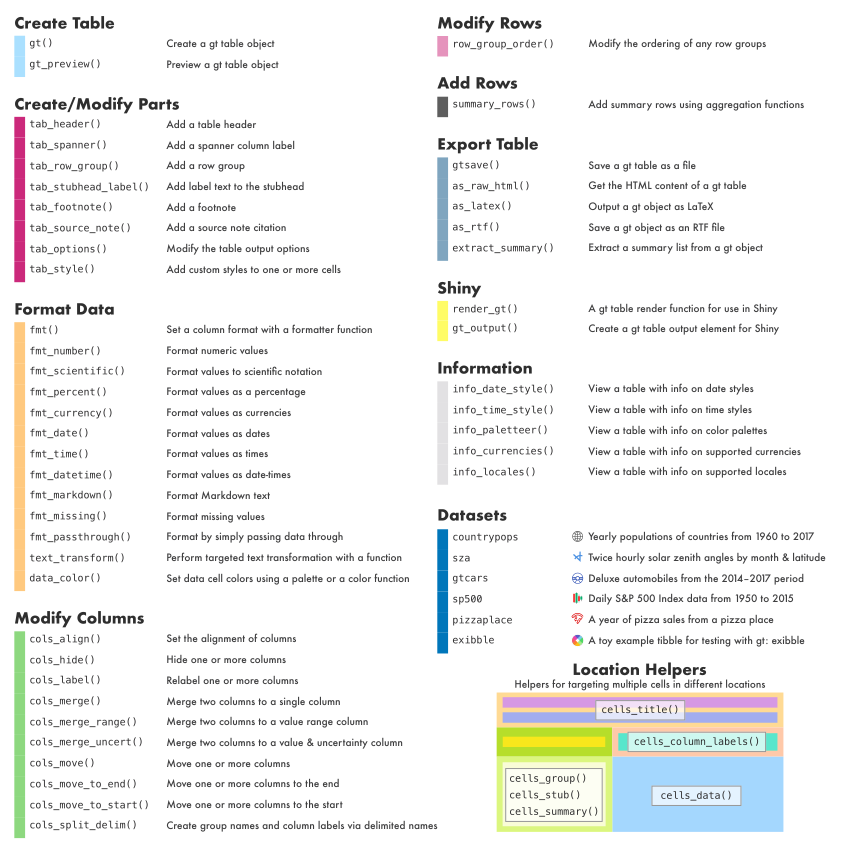

먼저 [`gtsummary`](http://www.danieldsjoberg.com/gtsummary/index.html) 팩키지에 포함된 `trial` 데이터셋을 바탕으로 다양한 표제작을 신속히 할 수 있는 방법을 살펴보자.

```r
library(gtsummary)

sample_tbl <-
  trial %>%
    select(trt, age, response) %>%
    na.omit()

sample_tbl
```

```
# A tibble: 183 × 3
   trt      age response
   <chr>  <dbl>    <int>
 1 Drug A    23        0
 2 Drug B     9        1
 3 Drug A    31        0
 4 Drug A    51        1
 5 Drug B    39        0
 6 Drug A    37        0
 7 Drug A    32        0
 8 Drug A    31        0
 9 Drug B    34        0
10 Drug B    42        0
# … with 173 more rows
```

`tbl_summary()` 함수를 사용해서 기본 생성 표를 제작해보자.

```r
sample_tbl %>%
  tbl_summary(by = "trt")
```

| **Characteristic** | **Drug A**, N = 89<sup>1</sup> | **Drug B**, N = 94<sup>1</sup> |
| --- | --- | --- |
| Age | 46 (37, 60) | 48 (38, 55) |
| Tumor Response | 27 (30%) | 31 (33%) |

<sup>*1*</sup> Median (IQR); n (%)

다음 단계로 필요한 요약 통계량을 뽑아내서 이를 표에 반영하는 방식을 살펴보자.

```r
gtsummary_tbl <-
  sample_tbl %>%
    tbl_summary(
      by = "trt",
      statistic = list(
        all_continuous() ~ "평균: {mean} (표준편차: {sd})",
        all_categorical() ~ "{n} / 총계: {N} (비율: {p}%)"
      ),
      label = list("age" ~ "연령",
              "response" ~ "반응")
    ) %>%
  modify_spanning_header(all_stat_cols() ~ "**신약**")

gtsummary_tbl
```

| **Characteristic** | **신약** **Drug A**, N = 89<sup>1</sup> | **신약** **Drug B**, N = 94<sup>1</sup> |
| --- | --- | --- |
| 연령 | 평균: 47 (표준편차: 15) | 평균: 47 (표준편차: 14) |
| 반응 | 27 / 총계: 89 (비율: 30%) | 31 / 총계: 94 (비율: 33%) |

<sup>*1*</sup> 평균: Mean (표준편차: SD); n / 총계: N (비율: %)

나름 필요한 정보가 모두 담긴 표가 제작되었으니 이를 `gt` 팩키지와 연결시켜 표를 제작해보자.

`gtsummary` 객체를 `gt()`에 연결시켜 작업하는 방법은 현재 없음.

```r
gtsummary_tbl %>%
  gt()
```

```
Error in UseMethod("group_vars"): no applicable method for 'group_vars' applied to an object of class "c('tbl_summary', 'gtsummary')"
```

[^1]: [`janitor` - tabyls: a tidy, fully-featured approach to counting things](https://cran.r-project.org/web/packages/janitor/vignettes/tabyls.html)
[^2]: [“R NOTES TO MYSELF”, “cleaning penguins with the janitor package”](http://jenrichmond.rbind.io/post/digging-into-the-janitor-package/)
[^3]: [Daniel D. Sjoberg (June 27, 2019), “`gtsummary` - Introduction to {gt} + {gtsummary} Packages”, Memorial Sloan Kettering Cancer Center](http://www.danieldsjoberg.com/gt-and-gtsummary-presentation/)
[^4]: [“What is the difference between sex and gender?”](https://www.ons.gov.uk/economy/environmentalaccounts/articles/whatisthedifferencebetweensexandgender/2019-02-21)
[^5]: [Daniel D. Sjoberg (June 27, 2019), “`gtsummary` - Introduction to {gt} + {gtsummary} Packages”, Memorial Sloan Kettering Cancer Center](http://www.danieldsjoberg.com/gt-and-gtsummary-presentation/)

데이터 과학자 [이광춘](https://github.com/statkclee/) 저작

*kwangchun.lee.7@gmail.com*